# Scraping Text Data

Troy Engelhardt

01/02/2018

**Prelude:** I am in no way affiliated with this data or the organisation where it was conceived. This project was undertook due to pure curiosity; mostly as an exercise of my R skills and ability to take unstructed, untouched data and create something meaningful from that. As the source of this data is a largely ungoverned, anonymous image/discussion board; the resulting text data, perhaps unsuprisingly, contains some strong, explicit language. If you think this language will offend you then I’d advise that you do not continue, however, if you’re not too phased by the language used by anonymous users of the internet then by all means carry on.

**A brief explaination of the data for some context:** This data is simply plain text taken from users who have posted through the infamous anonymous image/discussion board 4chan. There’s an ‘International’ section of the website where users are not *completely anonymous* but have a small flag attached to their post, indicating from which country the comment originated (although VPN’s could cloud this indicator of course). As you might expect, users tend to gravitate towards ‘general’ threads, which are simply discussion topics centered around a particular country or set of countries, however, this is merely a recommendation so users from other countries, ‘excluded’ from the general, can still freely post. There exists a ‘Australian & New Zealand’ based general which is where this simple text data has been sourced from.

```r
library('rvest')
```

```r
# working

getArchivedText <- function(thread){
  url <- thread
  webpage <- read_html(url)
  text_html <- html_nodes(webpage,'.text')
  text <- html_text(text_html)
  noreply_text <- gsub('>>[0-9]+', '', text)

  return(noreply_text)
}
```

```r
# working

url_num <- c('85054655', '85023543', '85001177', '84988480', '84978776', '84952756', '84940316', '84916976', '84901819', '84884081', '84862066', '84848942', '84820189', '84814935', '84808144')
```

```r
# working

for (id in url_num){
  assign(paste('thread_', id, sep = ""), getArchivedText(paste('https://desuarchive.org/int/thread/', id, '/#', id, sep = "")))
}
```

```r
plain_text <- c(thread_85054655, thread_85023543, thread_85001177, thread_84988480, thread_84978776, thread_84952756, thread_84940316, thread_84916976, thread_84901819, thread_84884081, thread_84862066, thread_84848942, thread_84820189, thread_84814935, thread_84808144)
```

```r
library(tm)
library(wordcloud)
```

```r
combined_text <- paste(plain_text, collapse = " ")
combined_source <- VectorSource(combined_text)
corp <- Corpus(combined_source)
```

```r
corp <- tm_map(corp, content_transformer(tolower))
corp <- tm_map(corp, removePunctuation)
corp <- tm_map(corp, stripWhitespace)
corp <- tm_map(corp, removeWords, stopwords('english'))
```

```r
dtm <- DocumentTermMatrix(corp)
dtm2 <- as.matrix(dtm)
```

```r
count <- colSums(dtm2)
count <- sort(count, decreasing = TRUE)
```

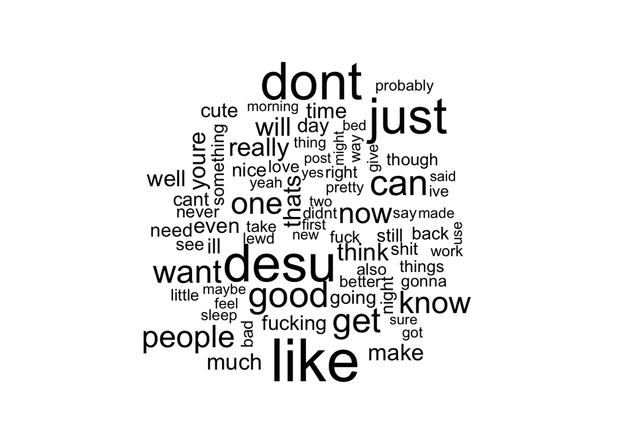

```r
words <- names(count)
wordcloud(words[1:75], count[1:75])
```

```r
count[1:75]
```

```
##      like      desu      dont      just       can      good       get
##       465       401       398       380       257       257       244
##      want       one      know    people       now      will    really
##       224       212       210       210       196       166       161
##     thats     think     youre      make      much      well      time
##       151       151       143       138       136       135       125
##      even       ill   fucking      cute       day      cant      nice
##       124       121       116       112       111       105       104
##     going      need     still something      back       see     night
##       103       103        97        92        91        91        90
##      shit     never      love    though       bad     right    things
##        90        87        84        84        82        82        82
##      fuck      also     gonna    better    little      take     didnt
##        81        80        80        78        77        76        74
##       ive       way      give      lewd       say     sleep      work
##        74        73        72        71        70        70        70
##    pretty  probably      yeah     thing     first       got      feel
##        69        69        69        67        66        66        65
##       use       two      made     maybe       new       bed      post
##        65        64        63        63        63        62        62
##       yes     might   morning      said      sure
##        62        61        61        61        61
```